# transition_manualの機能

[@anemptyarchive](https://www.anarchive-beta.com/)

2022/03/28

# transition_manual

`gganimate`パッケージの関数`transition_manual()`について解説します。`transition_manual()`は、アニメーション(gif画像)のフレーム切り替えを制御します。

利用するパッケージを読み込みます。

```r
# 利用するパッケージ
library(ggplot2)
library(gganimate)
library(magrittr)
```

基本的に`パッケージ名::関数名()`の記法で書きます。ただし作図コードに関してはごちゃごちゃしてしまうので、`ggplot2`パッケージの関数は関数名のみで、`gganimate`パッケージの関数はパッケージ名を明示します。`magrittr`からはパイプ演算子`%>%`を使います。

## データフレームの作成

まずは、作図に利用するデータフレームを作成します。

```r
# データフレームを作成
df <- tibble::tibble(
  x = 0:5,
  y = 0:5,
  frame = 0:5
)
df
```

```
## # A tibble: 6 x 3
##       x     y frame
##   <int> <int> <int>
## 1     0     0     0
## 2     1     1     1
## 3     2     2     2
## 4     3     3     3
## 5     4     4     4
## 6     5     5     5
```

分かりやすい値を作成しておきます。`tibble::tibble()`を使ってデータフレームを作成していますが、`data.frame()`を使っても問題ありません。

`transition_manual()`のフレームの引数`frames`(第1引数)に、フレームの順序を示す列を指定します。この例では、`frame`列が対応します。

作成したデータをグラフで確認しておきます。

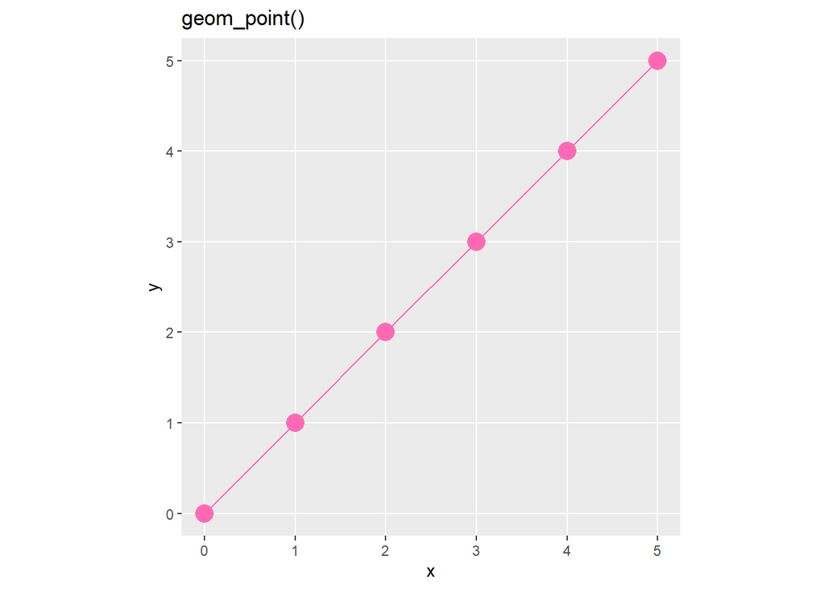

```r
# 折れ線グラフを作成
ggplot(df, aes(x = x, y = y)) +
  geom_point(size = 5, color = "hotpink") + # 散布図
  geom_path(color = "hotpink") + # 散布図
  scale_x_continuous(breaks = df[["x"]], minor_breaks = FALSE) + # x軸目盛
  scale_y_continuous(breaks = df[["y"]], minor_breaks = FALSE) + # y軸目盛
  coord_fixed(ratio = 1) + # アスペクト比
  labs(title = "geom_point()")
```

このデータを用いた散布図と折れ線グラフのアニメーションを通じて、`transition_manual()`の機能を確認していきます。

## ラベル変数

`transition_manual()`で使える3つのラベル変数(`previous_frame`・`current_frame`・`next_frame`)を確認します。

ラベル変数名を`{}`で挟んだ文字列を`labs()`などに指定します。

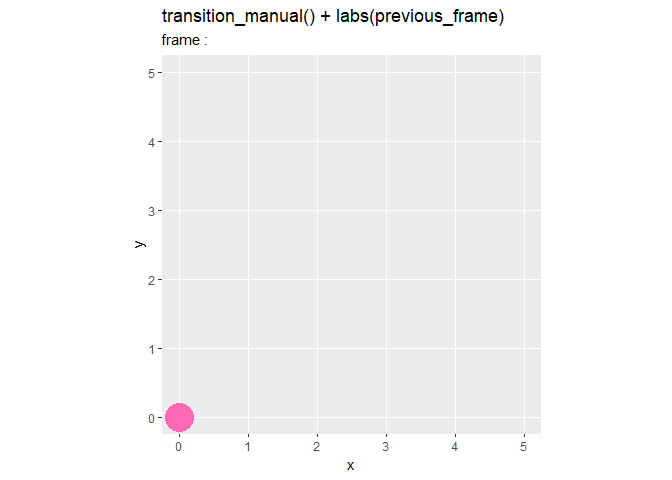

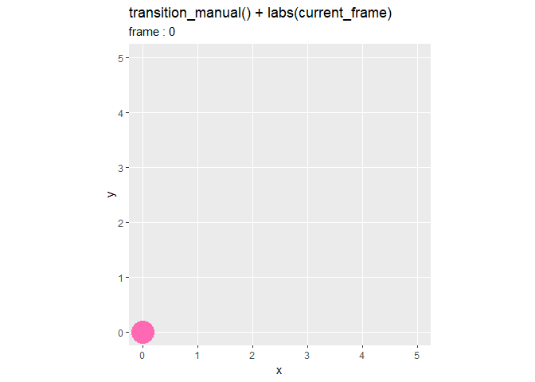

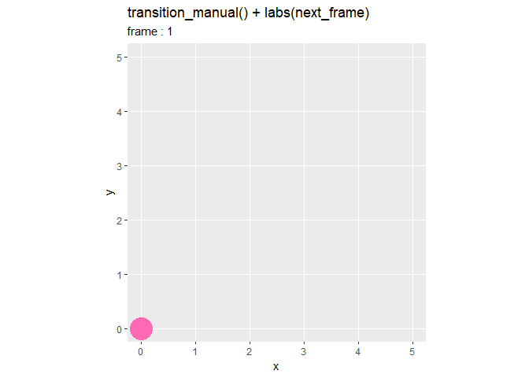

```r
# ラベル変数を指定
lv <- "previous_frame" # 前のデータの値
#lv <- "current_frame"  # 現在のデータの値
#lv <- "next_frame"     # 次のデータの値

# ラベル変数の設定
anim <- ggplot(df, aes(x = x, y = y)) +
  geom_point(size = 10, color = "hotpink") + # 散布図
  geom_path(color = "hotpink") + # 折れ線グラフ
  gganimate::transition_manual(frames = frame, cumulative = TRUE) + # フレーム
  scale_x_continuous(breaks = df[["x"]], minor_breaks = FALSE) + # x軸目盛
  scale_y_continuous(breaks = df[["y"]], minor_breaks = FALSE) + # y軸目盛
  coord_fixed(ratio = 1) + # アスペクト比
  labs(title = paste0("transition_manual() + labs(", lv, ")"),
       subtitle = paste0("frame : {", lv, "}"))

# gif画像を作成
gganimate::animate(plot = anim, nframes = 6, fps = 2)
```

解説用に複雑な作図コードになっていますが、`title = "{current_frame}"`のように指定してください。

## 引数

続いて、`transition_manual()`で利用できる2つの引数(`frame`・`cumulative`)を確認します。

### cumulative

`cumulative`引数は、現在のフレームのデータと一緒に、前のフレームのデータを描画するかを論理値で指定します。

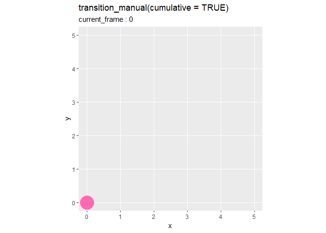

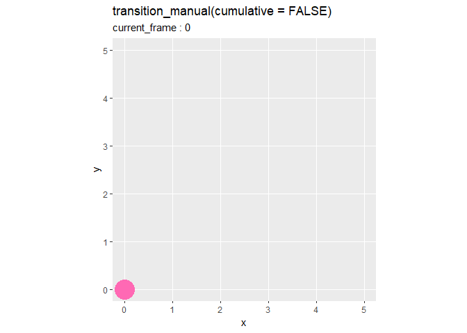

```r
# 論理値を指定:(デフォルト:FALSE)
b <- TRUE
#b <- FALSE

# cumulative(過去データの利用)の設定
anim <- ggplot(df, aes(x = x, y = y, group = 1)) +
  geom_point(size = 10, color = "hotpink") + # 散布図
  gganimate::transition_manual(frames = frame, cumulative = b) + # フレーム
  scale_x_continuous(breaks = df[["x"]], minor_breaks = FALSE) + # x軸目盛
  scale_y_continuous(breaks = df[["y"]], minor_breaks = FALSE) + # y軸目盛
  coord_fixed(ratio = 1) + # アスペクト比
  labs(title = paste0("transition_manual(cumulative = ", b, ")"),
       subtitle = paste0("current_frame : {current_frame}"))

# gif画像を作成
gganimate::animate(plot = anim, nframes = 6, fps = 2)
```

デフォルトは`FALSE`で、過去のフレームのデータを使いません。`TRUE`を指定すると、過去のデータも描画されます。  
この例では、`TRUE`だと最大6個の点が表示され、`FALSE`だと1個の点が移動するように描画されます。

### frames

`frames`引数(第1引数)に指定する値の影響を確認します。

まずは、重複しないランダムな整数をフレーム列とします。

```r
# データ数を指定
N <- 15

# ランダムに整数を生成
label_int <- sample(x = 1:N, size = N, replace = FALSE)

# データフレームを作成
df <- tibble::tibble(
  x = 1:N,
  y = 1:N,
  frame = label_int
)
head(df)
```

```
## # A tibble: 6 x 3
##       x     y frame
##   <int> <int> <int>
## 1     1     1     5
## 2     2     2     2
## 3     3     3    10
## 4     4     4     4
## 5     5     5    12
## 6     6     6     9
```

このデータフレームを用いて、グラフを作成します。

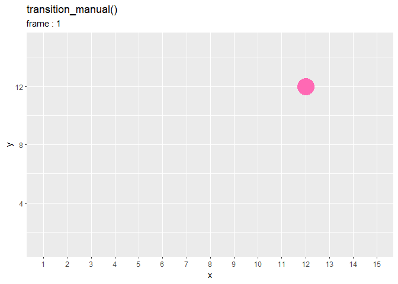

```r
# frames(フレーム切替)の設定
anim <- ggplot(df, aes(x = x, y = y, group = 1)) +
  geom_point(size = 10, color = "hotpink") + # 散布図
  geom_path(color = "hotpink") + # 折れ線グラフ
  gganimate::transition_manual(frames = frame, cumulative = TRUE) + # フレーム
  scale_x_continuous(breaks = 1:N, minor_breaks = FALSE) + # x軸目盛
  labs(title = "transition_manual()",
       subtitle = "frame : {current_frame}")

# gif画像を作成
gganimate::animate(plot = anim, nframes = N, fps = 3)
```

`frames`引数に指定した列の値が小さい順に描画されます。

昇順に並べ替えると次のようになります。

```r
# フレーム列で昇順に並び替え
df %>%
  dplyr::arrange(frame) %>%
  head()
```

```
## # A tibble: 6 x 3
##       x     y frame
##   <int> <int> <int>
## 1    12    12     1
## 2     2     2     2
## 3    13    13     3
## 4     4     4     4
## 5     1     1     5
## 6     7     7     6
```

点が表示される順番と一致しているのが分かります。

次は、フレーム列の値が等間隔でない場合を見ます。

```r
# ランダムな間隔の整数を生成
label_int <- sample(x = 1:(N*10), size = N, replace = FALSE) %>%
  sort()
label_int
```

```
##  [1]   4   6  18  41  42  63  73  82  86 108 113 114 116 131 139
```

分かりやすいように`sort()`で昇順に並び替えておきます。

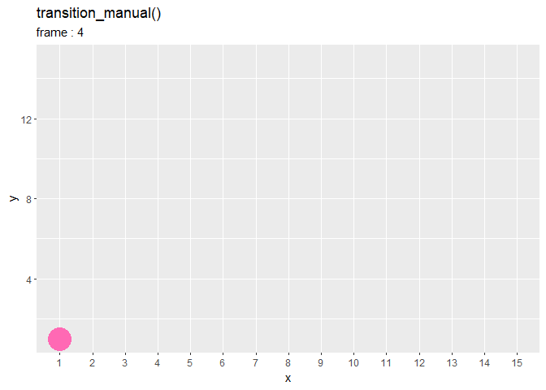

値の間隔は影響せずに描画されました。

フレーム列の値が重複する場合を見ます。

```r
# ランダムに整数を生成
label_int <- sample(x = 1:N, size = N, replace = TRUE) %>%
  sort()
label_int
```

```
##  [1]  1  2  3  4  4  4  5  8  8  9 11 12 13 13 15
```

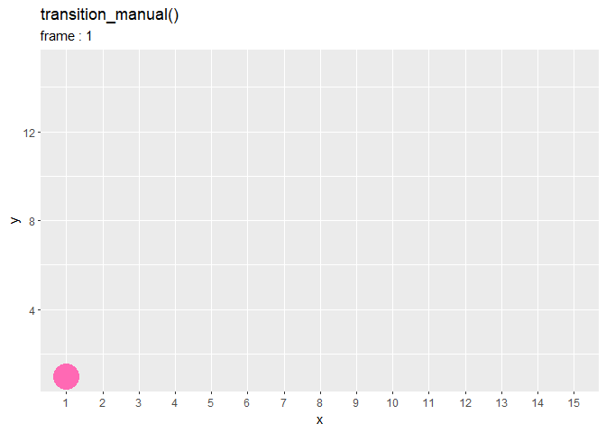

値が重複する複数の点(複数行のデータ)が同じフレームに描画されました。

続いて、文字列を指定してみます。

```r
# 文字列のラベルを作成
label_chr <- paste0("n=", 1:N)

# データフレームを作成
df <- tibble::tibble(
  x = 1:N,
  y = 1:N,
  frame = label_chr
)
head(df)
```

```
## # A tibble: 6 x 3
##       x     y frame
##   <int> <int> <chr>
## 1     1     1 n=1
## 2     2     2 n=2
## 3     3     3 n=3
## 4     4     4 n=4
## 5     5     5 n=5
## 6     6     6 n=6
```

`n=`は同じで、その後の文字を通し番号とします。

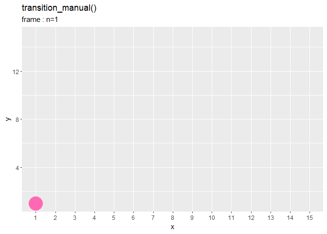

意図しない順になりました。

フレーム列で昇順に並び替えてみます。

```r
# フレーム列で昇順に並び替え
df %>%
  dplyr::arrange(frame)
```

```
## # A tibble: 15 x 3
##        x     y frame
##    <int> <int> <chr>
##  1     1     1 n=1
##  2    10    10 n=10
##  3    11    11 n=11
##  4    12    12 n=12
##  5    13    13 n=13
##  6    14    14 n=14
##  7    15    15 n=15
##  8     2     2 n=2
##  9     3     3 n=3
## 10     4     4 n=4
## 11     5     5 n=5
## 12     6     6 n=6
## 13     7     7 n=7
## 14     8     8 n=8
## 15     9     9 n=9
```

辞書の並びのように、3文字目の`1`によって意図しない並びになっています。

これは次のようにも確認できます。

```r
# 昇順に並び替え
sort(label_chr)
```

```
##  [1] "n=1"  "n=10" "n=11" "n=12" "n=13" "n=14" "n=15" "n=2"  "n=3"  "n=4"
## [11] "n=5"  "n=6"  "n=7"  "n=8"  "n=9"
```

文字列型から因子型に変換して使います。

```r
# 因子型のラベルを作成
label_fct <- factor(label_chr, levels = label_chr)

# データフレームを作成
df <- tibble::tibble(
  x = 1:N,
  y = 1:N,
  frame = label_fct
)
head(df)
```

```
## # A tibble: 6 x 3
##       x     y frame
##   <int> <int> <fct>
## 1     1     1 n=1
## 2     2     2 n=2
## 3     3     3 n=3
## 4     4     4 n=4
## 5     5     5 n=5
## 6     6     6 n=6
```

`factor()`のレベルの`level`引数にも`label_chr`を指定します。

昇順に並び替えて確認します。

```r
# 昇順に並び替え
sort(label_fct)
```

```
##  [1] n=1  n=2  n=3  n=4  n=5  n=6  n=7  n=8  n=9  n=10 n=11 n=12 n=13 n=14 n=15
## 15 Levels: n=1 n=2 n=3 n=4 n=5 n=6 n=7 n=8 n=9 n=10 n=11 n=12 n=13 ... n=15
```

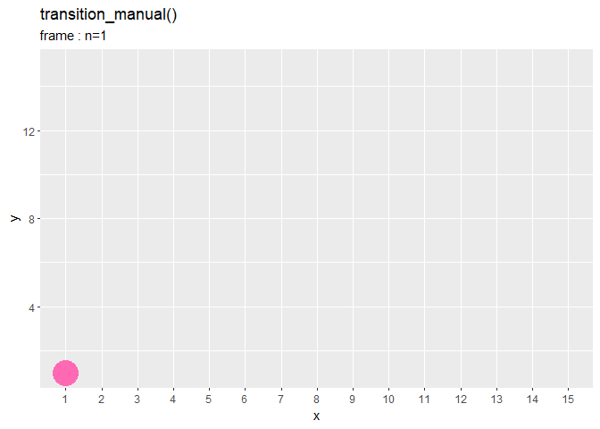

因子型のレベルを指定することで、意図したグラフになりました。  
ただし、このグラフを素直に作るなら、数値のフレーム列を作り`"n={current_frame}"`とします。

以上で、ラベル変数と引数の機能を確認できました。次は、実用を想定してグラフを作成します。

## 利用例：サイコロ

`gganimate`パッケージの使用例として、サイコロの出目の頻度を可視化します。

利用するパッケージを読み込みます。

```r
# 利用するパッケージ
library(tidyverse)
library(gganimate)
```

### データの生成

まずは、利用するデータを作成します。

```r
# 試行回数を指定
N <- 30

# 面の数を指定
V <- 6

# サイコロを振る
result_mat <- rmultinom(n = N, size = 1, prob = rep(1 / V, times = V)) %>%
  t()
result_mat[1:5, ]
```

```
##      [,1] [,2] [,3] [,4] [,5] [,6]
## [1,]    0    0    0    1    0    0
## [2,]    0    1    0    0    0    0
## [3,]    0    0    0    0    1    0
## [4,]    0    0    1    0    0    0
## [5,]    0    0    0    1    0    0
```

サイコロを振った結果は、多項分布の乱数生成関数`rmultinom()`で再現できます。  
試行回数の引数`n`に`N`、1試行当たりのサイコロの数の引数`size`に`1`、サイコロの各面の確率の引数`prob`に一様な確率`1 / V`を指定します。

`rmultinom()`の出力を`t()`で転置しておきます。行が各試行、列が各面に対応しており、値が`1`の列番号が出た目を表します。

出目の値を抽出します。

```r
# 出目を抽出
result_vec <- which(t(result_mat) == 1, arr.ind = TRUE)[, "row"]
result_vec[1:5]
```

```
## [1] 4 2 5 3 4
```

`result_mat`に対して、値が`1`の列番号を抽出します。  
`which()`は、条件に合う要素の行番号と列番号を返します。`result_mat`を転置して渡す必要があります。転置するので、行番号(`"row"`列)を取り出します。

サイコロを振った結果が得られたので、アニメーションで可視化していきます。

### 折れ線グラフによる可視化

試行回数と出た目の値をデータフレームに格納します。

```r
# 結果を格納
result_df <- tibble::tibble(
  v = c(NA_integer_, result_vec),
  n = 0:N
)
head(result_df)
```

```
## # A tibble: 6 x 2
##       v     n
##   <int> <int>
## 1    NA     0
## 2     4     1
## 3     2     2
## 4     5     3
## 5     3     4
## 6     4     5
```

グラフの変化を分かりやすくするために、0回目の結果に相当する行を追加します。出目はないので(整数型の)欠損値`NA_integer_`を使います。

出目の推移のグラフを作成します。

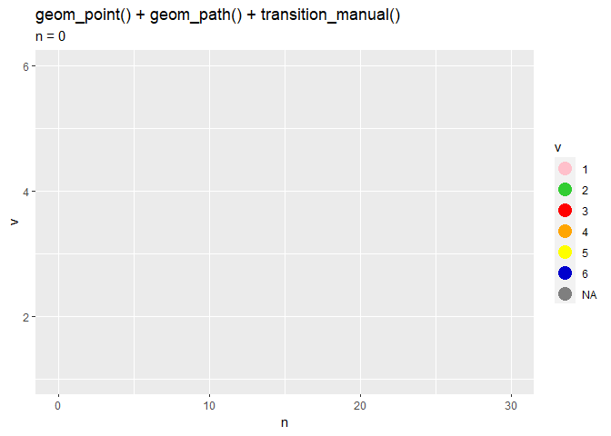

```r
# 出目の推移を作図
anim <- ggplot(result_df, aes(x = n, y = v)) +
  geom_path(color = "hotpink") + # 折れ線グラフ
  geom_point(mapping = aes(color = factor(v)), size = 5) + # 散布図
  scale_color_manual(values = c("pink", "limegreen", "red", "orange", "yellow", "mediumblue")) + # 枠線の色:(不必要)
  gganimate::transition_manual(frames = n, cumulative = TRUE) +
  labs(title = "geom_point() + geom_path() + transition_manual()",
       subtitle = "n = {current_frame}",
       color = "v")

# gif画像を作成
gganimate::animate(plot = anim, nframes = N+1, fps = 5)
```

散布図と折れ線グラフを重ねて描画します。

次は、頻度に注目します。

各試行までに出た目の数をそれぞれカウントします。

```r
# 出目を集計
count_df <- result_mat %>%
  tibble::as_tibble() %>% # データフレームに変換
  cumsum() %>% # 試行ごとに集計
  dplyr::mutate(n = 1:N) %>% # 試行回数列を追加
  tidyr::pivot_longer(
    cols = -n,
    names_to = "v",
    names_prefix = "V",
    names_ptypes = list(v = factor()),
    values_to = "count"
  ) %>% # 縦型のデータフレームに変換
  rbind(
    tibble::tibble(
      n = rep(0, times = V),
      v = factor(1:V),
      count = rep(0, times = V)
    ),
    .
  ) # 0回目の結果を追加

# 1回から3回目時点の結果
count_df %>%
  dplyr::filter(n >= 1, n <= 3)
```

```
## # A tibble: 18 x 3
##        n v     count
##    <dbl> <fct> <dbl>
##  1     1 1         0
##  2     1 2         0
##  3     1 3         0
##  4     1 4         1
##  5     1 5         0
##  6     1 6         0
##  7     2 1         0
##  8     2 2         1
##  9     2 3         0
## 10     2 4         1
## 11     2 5         0
## 12     2 6         0
## 13     3 1         0
## 14     3 2         1
## 15     3 3         0
## 16     3 4         1
## 17     3 5         1
## 18     3 6         0
```

`cumsum()`で累積和(`1`行目から`n`行目までの和)を計算します。  
最後にこちらも、0回目の結果に相当する行(`V`行のデータフレーム)を追加します。

各面の出現回数の推移のグラフを作成します

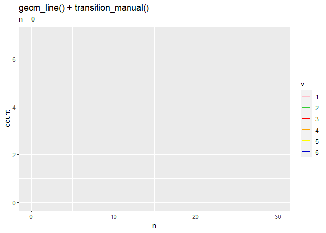

```r
# 出目の推移を作図
anim <- ggplot() +
  geom_line(data = count_df, mapping = aes(x = n, y = count, color = v), size = 1) + # 折れ線グラフ
  scale_color_manual(values = c("pink", "limegreen", "red", "orange", "yellow", "mediumblue")) + # 枠線の色:(不必要)
  gganimate::transition_manual(frames = n, cumulative = TRUE) +
  labs(title = "geom_line() + transition_manual()",
       subtitle = "n = {current_frame}")

# gif画像を作成
gganimate::animate(plot = anim, nframes = N+1, fps = 5)
```

面(`v`列)ごとに色分けしてそれぞれ折れ線グラフを描画します。

ここに装飾を付け足します。

試行回数の列`n`と同じ値を持つ`frame`列を作成しておきます。

```r
# フレーム切替用の列を追加
count_df <- count_df %>%
  dplyr::mutate(frame = n)
head(count_df)
```

```
## # A tibble: 6 x 4
##       n v     count frame
##   <dbl> <fct> <dbl> <dbl>
## 1     0 1         0     0
## 2     0 2         0     0
## 3     0 3         0     0
## 4     0 4         0     0
## 5     0 5         0     0
## 6     0 6         0     0
```

試行回数(`n`列)とフレーム数(`frame`列)が一致したこのデータフレームとは別に、データを重複して持つデータフレームを用意します。

`n`フレーム目(`frame`列が`n`)のときに、`0`から`n`回目の結果(`n`列が`0`から`n`)を持つデータフレームを作成します。

```r
# 過去の試行を複製
count_df2 <- count_df %>%
  dplyr::mutate(num = rep((N+1):1, each = V)) %>% # 複製する数を追加
  tidyr::uncount(num) %>% # 行を複製
  dplyr::group_by(n, v) %>% # グループ化
  dplyr::mutate(frame = N + 1 - dplyr::row_number()) %>% # フレーム番号を書き替え
  dplyr::ungroup() %>% # グループ化を解除
  dplyr::arrange(frame, n, v) # 昇順に並び替え

# 2フレームに表示するデータ
count_df2 %>%
  dplyr::filter(frame == 2)
```

```
## # A tibble: 18 x 4
##        n v     count frame
##    <dbl> <fct> <dbl> <dbl>
##  1     0 1         0     2
##  2     0 2         0     2
##  3     0 3         0     2
##  4     0 4         0     2
##  5     0 5         0     2
##  6     0 6         0     2
##  7     1 1         0     2
##  8     1 2         0     2
##  9     1 3         0     2
## 10     1 4         1     2
## 11     1 5         0     2
## 12     1 6         0     2
## 13     2 1         0     2
## 14     2 2         1     2
## 15     2 3         0     2
## 16     2 4         1     2
## 17     2 5         0     2
## 18     2 6         0     2
```

`0`回目の結果は全てのフレームで利用するので、`N+1`行に複製します。`N`回目(最後)の結果は最後のフレームのみで利用するので、`1`行のままです。よって、`(N+1):1`の値を持つ列を追加します。ただし、それぞれ`V`面(行)分の結果があるので、`rep()`で複製します。  
`uncount()`で、追加した値の行数をそれぞれ複製します。重複した行数を数える`count()`の逆の処理です。  
`row_number()`で、複製した行ごとに通し番号を付与します。試行回数(`n`列)とサイコロの目ん(`v`列)でグループ化します。

出目の推移のグラフを作成します。

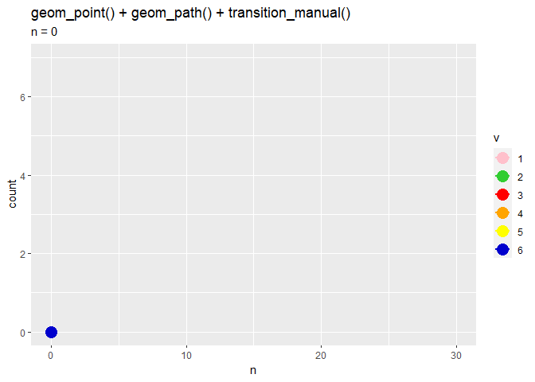

```r
# 出目の出現回数の推移を作図
anim <- ggplot() +
  geom_point(data = count_df, mapping = aes(x = n, y = count, color = v),
             size = 5) + # 散布図
  geom_path(data = count_df2, mapping = aes(x = n, y = count, color = v),
            size = 1) + # 折れ線グラフ
  gganimate::transition_manual(frames = frame, cumulative = FALSE) +
  scale_color_manual(values = c("pink", "limegreen", "red", "orange", "yellow", "mediumblue")) + # 枠線の色:(不必要)
  labs(title = "geom_point() + geom_path() + transition_manual()",
       subtitle = "n = {current_frame}")

# gif画像を作成
gganimate::animate(plot = anim, nframes = N+1, fps = 5)
```

過去のデータを持つデータフレームを用意したので、`couulativ`引数を`FALSE`にします(グラフごとに切り替えられたら楽なのだが)。

棒グラフでも可視化します。

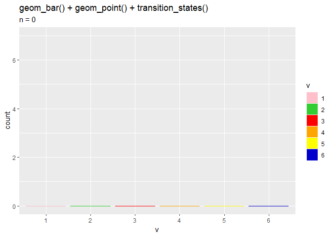

```r
# 出目の出現回数の推移を作図
anim <- ggplot() +
  geom_bar(data = count_df, mapping = aes(x = v, y = count, fill = v, color = v),
           stat = "identity") + # 棒グラフ
  geom_point(data = result_df, mapping = aes(x = v, y = 0),
             color = "hotpink", size = 5) + # 散布図
  scale_fill_manual(values = c("pink", "limegreen", "red", "orange", "yellow", "mediumblue")) + # バーの色:(不必要)
  scale_color_manual(values = c("pink", "limegreen", "red", "orange", "yellow", "mediumblue")) + # 枠線の色:(不必要)
  gganimate::transition_manual(frames = n) +
  labs(title = "geom_bar() + geom_point() + transition_states()",
       subtitle = "n = {current_frame}")

# gif画像を作成
gganimate::animate(plot = anim, nframes = N+1, fps = 5)
```

次は、出現数の順位に注目します。

各試行における出目の合計の順位を追加します。

```r
# 出目の数により順位付け
rank_df <- count_df %>%
  dplyr::group_by(n) %>% # グループ化
  dplyr::mutate(ranking = dplyr::row_number(-count)) %>% # 順位列を追加
  dplyr::ungroup() # グループ化の解除

# 出目の数により順位付け
rank_df2 <- count_df2 %>%
  dplyr::group_by(n, frame) %>% # グループ化
  dplyr::mutate(ranking = dplyr::row_number(-count)) %>% # 順位列を追加
  dplyr::ungroup() # グループ化の解除
head(rank_df)
```

```
## # A tibble: 6 x 5
##       n v     count frame ranking
##   <dbl> <fct> <dbl> <dbl>   <int>
## 1     0 1         0     0       1
## 2     0 2         0     0       2
## 3     0 3         0     0       3
## 4     0 4         0     0       4
## 5     0 5         0     0       5
## 6     0 6         0     0       6
```

`row_number()`で、昇順に整数を割り当てられます。ここでは、試行ごとに割り当てたいので`n`列でグループ化して、また出現回数`count`列が多い順に割り当てたいのでマイナス`-`を付けて大小関係を入れ変えています。  
過去データを重複して持つデータフレームについては、試行回数`n`列とフレーム番号`frame`列でグループ化します。

出現回数の順位の推移のグラフを作成します。

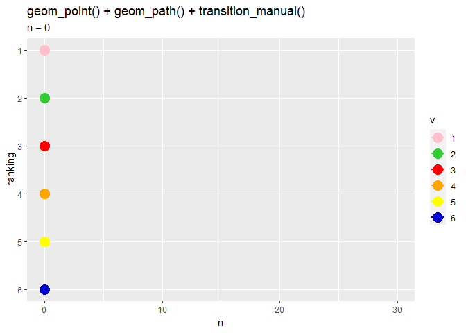

```r
# 出目の出現回数の順位の推移を作図
anim <- ggplot() +
  geom_point(data = rank_df, mapping = aes(x = n, y = ranking, color = v, group = v),
             size = 5) + # 散布図
  geom_path(data = rank_df2, mapping = aes(x = n, y = ranking, color = v, group = v),
            size = 1) + # 折れ線グラフ
  gganimate::transition_manual(frames = frame, cumulative = FALSE) +
  scale_y_reverse(breaks = 1:V, minor_breaks = FALSE) + #
  scale_color_manual(values = c("pink", "limegreen", "red", "orange", "yellow", "mediumblue")) + # 枠線の色:(不必要)
  labs(title = "geom_point() + geom_path() + transition_manual()",
       subtitle = "n = {current_frame}")

# gif画像を作成
gganimate::animate(plot = anim, nframes = N+1, fps = 5)
```

y軸をランキングにします。ただし、値が小さい(順位が高い)方を上にするため`scale_y_reverse()`を使います。

### ラベル変数の加工

続いて、サブタイトルに各面の出現回数を表示します。基本的な処理は先ほどと同じです。

フレームごとに各面の出現回数を示す文字列を作成します。

```r
# 出目の出現回数を集計
count_label_df <- result_mat %>%
  tibble::as_tibble() %>% # データフレームに変換
  cumsum() %>% # 試行ごとに集計
  dplyr::mutate(n = 1:N) %>% # 試行回数列を追加
  dplyr::group_by(n) %>% # 試行回数でグループ化
  dplyr::mutate(
    label = paste0(dplyr::across(V1:V6), collapse = ", ") %>%
      paste0("n=", n, "=(", ., ")") %>%
      as.factor()
  ) %>% # フレーム切替用のラベルを作成
  tidyr::pivot_longer(
    cols = -c(n, label),
    names_to = "v",
    names_prefix = "V",
    names_ptypes = list(v = factor()),
    values_to = "count"
  ) %>% # 縦型のデータフレームに変換
  rbind(
    tibble::tibble(
      n = rep(0, times = V),
      label = paste0("n=0=(", paste0(rep(0, times = V), collapse = ", "), ")") %>%
        as.factor(),
      v = factor(1:V),
      count = rep(0, times = V)
    ),
    .
  ) # 0回目の結果を追加
head(count_label_df)
```

```
## # A tibble: 6 x 4
##       n label                  v     count
##   <dbl> <fct>                  <fct> <dbl>
## 1     0 n=0=(0, 0, 0, 0, 0, 0) 1         0
## 2     0 n=0=(0, 0, 0, 0, 0, 0) 2         0
## 3     0 n=0=(0, 0, 0, 0, 0, 0) 3         0
## 4     0 n=0=(0, 0, 0, 0, 0, 0) 4         0
## 5     0 n=0=(0, 0, 0, 0, 0, 0) 5         0
## 6     0 n=0=(0, 0, 0, 0, 0, 0) 6         0
```

`across()`で、1の面の出現回数(`V1`列)から6の面の出現回数(`V6`列)をまとめて、`paste0()`で結合し、因子型に変換します。

ラベル列(フレーム列)を取り出しておきます。

```r
# ラベルを取り出す
label_vec <- unique(count_label_df[["label"]])
```

試行ごとに過去データを複製します。

```r
# 過去の試行を複製
count_label_df2 <- count_label_df %>%
  dplyr::mutate(num = rep((N+1):1, each = V)) %>% # 複製する数を追加
  tidyr::uncount(num) %>% # 行を複製
  dplyr::group_by(n, v) %>% # グループ化
  dplyr::mutate(
    idx = N + 1 - dplyr::row_number(),
    label = label_vec[idx+1]
  ) %>% # フレーム切替用のラベルを追加
  dplyr::ungroup() %>% # グループ化を解除
  dplyr::arrange(label, n, v) # 昇順に並び替え
head(count_label_df2)
```

```
## # A tibble: 6 x 5
##       n label                  v     count   idx
##   <dbl> <fct>                  <fct> <dbl> <dbl>
## 1     0 n=0=(0, 0, 0, 0, 0, 0) 1         0     0
## 2     0 n=0=(0, 0, 0, 0, 0, 0) 2         0     0
## 3     0 n=0=(0, 0, 0, 0, 0, 0) 3         0     0
## 4     0 n=0=(0, 0, 0, 0, 0, 0) 4         0     0
## 5     0 n=0=(0, 0, 0, 0, 0, 0) 5         0     0
## 6     0 n=0=(0, 0, 0, 0, 0, 0) 6         0     0
```

複製した行ごとに通し番号を付けて`idx`列とします。`idx`列の値を添字として用いて、対応するラベルと付与します。

出目の推移のグラフを作成します。

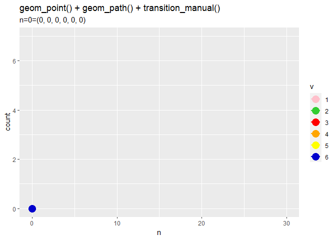

```r
# 出目の出現回数の推移を作図
anim <- ggplot() +
  geom_point(data = count_label_df, mapping = aes(x = n, y = count, color = v),
             size = 5) + # 散布図
  geom_path(data = count_label_df2, mapping = aes(x = n, y = count, color = v),
            size = 1) + # 折れ線グラフ
  gganimate::transition_manual(frames = label) +
  scale_color_manual(values = c("pink", "limegreen", "red", "orange", "yellow", "mediumblue")) + # 枠線の色:(不必要)
  labs(title = "geom_point() + geom_path() + transition_manual()",
       subtitle = "{current_frame}")

# gif画像を作成
gganimate::animate(plot = anim, nframes = N+1, fps = 5)
```

棒グラフでも可視化します。

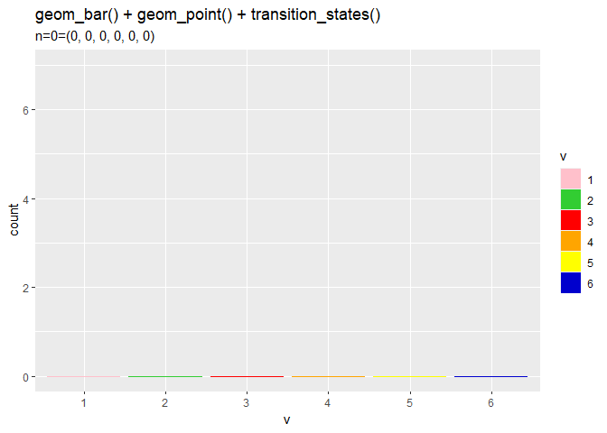

```r
# 結果を格納
result_label_df <- tibble::tibble(
  v = c(NA_integer_, result_vec),
  n = 0:N,
  label = unique(count_label_df[["label"]])
)


# 出目の出現回数の推移を作図
anim <- ggplot() +
  geom_bar(data = count_label_df, mapping = aes(x = v, y = count, fill = v, color = v),
           stat = "identity") + # 棒グラフ
  geom_point(data = result_label_df, mapping = aes(x = v, y = 0),
             color = "hotpink", size = 5) + # 散布図
  scale_fill_manual(values = c("pink", "limegreen", "red", "orange", "yellow", "mediumblue")) + # バーの色:(不必要)
  scale_color_manual(values = c("pink", "limegreen", "red", "orange", "yellow", "mediumblue")) + # 枠線の色:(不必要)
  gganimate::transition_manual(frames = label) +
  labs(title = "geom_bar() + geom_point() + transition_states()",
       subtitle = "{current_frame}")

# gif画像を作成
gganimate::animate(plot = anim, nframes = N+1, fps = 5)
```

ランキング列を作成します。

```r
# ランク付け
rank_label_df <- count_label_df %>%
  dplyr::group_by(n) %>% # グループ化
  dplyr::mutate(ranking = dplyr::row_number(-count)) %>% # ランキング列を追加
  dplyr::ungroup() # グループ化の解除

# ランク付け
rank_label_df2 <- count_label_df2 %>%
  dplyr::group_by(n, label) %>% # グループ化
  dplyr::mutate(ranking = dplyr::row_number(-count)) %>% # ランキング列を追加
  dplyr::ungroup() # グループ化の解除
head(rank_label_df2)
```

```
## # A tibble: 6 x 6
##       n label                  v     count   idx ranking
##   <dbl> <fct>                  <fct> <dbl> <dbl>   <int>
## 1     0 n=0=(0, 0, 0, 0, 0, 0) 1         0     0       1
## 2     0 n=0=(0, 0, 0, 0, 0, 0) 2         0     0       2
## 3     0 n=0=(0, 0, 0, 0, 0, 0) 3         0     0       3
## 4     0 n=0=(0, 0, 0, 0, 0, 0) 4         0     0       4
## 5     0 n=0=(0, 0, 0, 0, 0, 0) 5         0     0       5
## 6     0 n=0=(0, 0, 0, 0, 0, 0) 6         0     0       6
```

出現回数の順位のグラフを作成します。

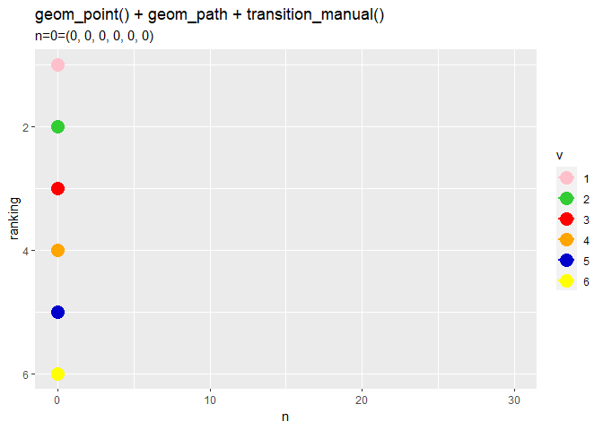

```r
# 出目の出現回数の順位の推移を作図
anim <- ggplot() +
  geom_point(data = rank_label_df, mapping = aes(x = n, y = ranking, color = v, group = v),
             size = 5) + # 散布図
  geom_path(data = rank_label_df2, mapping = aes(x = n, y = ranking, color = v, group = v),
            size = 1) + # 散布図
  scale_y_reverse() +
  scale_color_manual(values = c("pink", "limegreen", "red", "orange", "mediumblue", "yellow")) + # 枠線の色:(不必要)
  gganimate::transition_manual(frames = label, cumulative = FALSE) +
  labs(title = "geom_point() + geom_path + transition_manual()",
       subtitle = "{current_frame}")

# gif画像を作成
gganimate::animate(plot = anim, nframes = N+1, fps = 5)
```